# SARS-CoV-2 vaccine acceptance in Germany: Do trust in health care professionals make a difference?)

Zehui Bai

# Data Exploration

## Fragesetllung

Question 4/3: Wurden Sie gegen Corona geimpft? (ImpfZust)

## Selection of variables

Following variable are selected from the questionares:

- Perception of disease risk: 4/1; 4/2 (code)
  - Question 4/1: Kennen Sie Personen, die an Corona erkrankt sind? (PersoKenn)
  - Question 4/2: Hatte mindestens eine dieser Personen einen schweren Krankheitsverlauf? (KennErkr)
- Attitude towards vaccination (ImpGrund):
  - Question 4/16: Warum haben/ wollen Sie sich gegen Corona impfen lassen?
    - ImpGrund[beruf] Ich habe/ möchte mich aus beruflichen Gründen impfen lassen
    - ImpGrund[risiko] Ich möchte das Risiko einer Corona-Infektion verringern
    - ImpGrund[norm] Ich möchte schnell zum normalen Leben zurückkehren
    - ImpGrund[gesfam] Ich möchte die Gesundheit meiner Familie schützen
    - ImpGrund[sozum] Ich werde/ wurde von meinem sozialen Umfeld angetrieben
    - ImpGrund[gesell] Ich bin der Meinung, dass die Impfung einen wichtigen gesellschaftlichen Beitrag darstellt
    - ImpGrund[geswesent] Ich bin der Meinung, dass die Impfung einen wichtigen gesellschaftlichen Beitrag darstellt
- One’s own health status:
  - Question 2/2: Wie schätzen Sie Ihren allgemeinen körperlichen Gesundheitszustand im Durchschnitt über die letzten sechs Monate ein? (GesuZuK)
  - Question 2/3: Wie schätzen Sie Ihren allgemeinen psychischen Gesundheitszustand im Durchschnitt über die letzten sechs Monate ein? (GesuZuPsy)
  - Question 2/4: Welche der folgenden Impfungen haben Sie bereits erhalten?
    - Anam[HepB] Hepatitis B
    - Anam[Fern] Impfungen für Fernreisen (wie z.B. Japanische Enzephalitis, Gelbfieber, Typhus, Tollwut)
    - Anam[Inf] Influenza (mind. 1mal)
    - Anam[Mas] Masern
    - Anam[Mum] Mumps
    - Anam[Roet] Röteln
    - Anam[Pol] Polio (Kinderlähmung)
    - Anam[Nicht] Ich bin mir über meinen Impfstatus nicht sicher
    - Anam[Keine] Ich habe keine der hier aufgelisteten Impfungen erhalten
- Socio-demographic data:
  - Question 1/1: Bitte geben Sie Ihr Alter in Jahren an (Age)
  - Question 2/1: Welchem Geschlecht fühlen Sie sich zugehörig (Sex)
- Socio-economic status
  - Question 8/1: Was ist Ihr höchster Schulabschluss (Schulab)
  - Question 8/2: Was ist Ihr höchster beruflicher Abschluss? (BerufAb)
  - Question 8/3: Wie ist Ihr aktuelles Beschäftigungsverhältnis?
  - Question 8/4: Sind/ Waren Sie beruflich im Gesundheitswesen tätig? (TaetGes)
  - Question 8/5: In welchem Bereich sind/ waren Sie tätig? (TaetGesBer)
- Access to health information
  - Question 6/5: Wie oft informieren Sie sich bewusst über Corona? (ZeitInfo)
- Trust in government
  - Question 5/8: Wie zufrieden sind Sie mit der Arbeit der folgenden Einrichtungen während der Corona-Pandemie (in score transform)
- Compliance with health professionals
  - Question 5/4: Wie schätzen Sie die Qualität der Behandlung dieses Arztes/dieser Ärztin im Allgemeinen ein? (zapaQualBe)
  - Question 5/5: Werden/Wurden Sie durch einen Arzt/eine Ärztin über die Corona Impfungen aufgeklärt? (zapaImpf)
  - Question 5/6: Haben sie aktiv nach einer Aufklärung gefragt? (AufklAkt)
  - Question 5/7: Waren Sie zufrieden mit der Aufklärung über die Impfung (ZufriedAufk)
- Internet and social media (convert the variable)
  - Question 6/4: Bitte geben Sie an, wie oft Sie mit den folgenden Personengruppen über Corona sprechen. (**not find**)
- Additional analysis
  - Question 4/5: Wie viele Corona-Impfungen haben Sie bis jetzt erhalten? (ImpDos)
  - Question 9/5: Wie viele Personen leben in Ihrem Haushalt (Sie mit eingeschlossen)? (PersHaus)
  - Question 6/2: Bitte geben Sie an, welche der nachfolgenden Informationsquellen Sie bei der Suche nach allgemeinen Informationen nutzen und wie häufig.
  - Question 6/4: Bitte geben Sie an, wie oft Sie mit den folgenden Personengruppen über Corona sprechen. (Face2Face[Fam],Face2Face[Fachpers])
  - Question 9/6: Wie hoch ist Ihr monatliches Nettoeinkommen? (Eink)

## Variable convertion

For the Question “Question 4/16: Warum haben/ wollen Sie sich gegen Corona impfen lassen?”, the 7 sub questions will be regarded as seperate variables to explore the effects of different reason for vaccination. + ImpGrund[beruf] Ich habe/ möchte mich aus beruflichen Gründen impfen lassen + ImpGrund[risiko] Ich möchte das Risiko einer Corona-Infektion verringern + ImpGrund[norm] Ich möchte schnell zum normalen Leben zurückkehren + ImpGrund[gesfam] Ich möchte die Gesundheit meiner Familie schützen + ImpGrund[sozum] Ich werde/ wurde von meinem sozialen Umfeld angetrieben + ImpGrund[gesell] Ich bin der Meinung, dass die Impfung einen wichtigen gesellschaftlichen Beitrag darstellt + ImpGrund[geswesent] Ich bin der Meinung, dass die Impfung einen wichtigen gesellschaftlichen Beitrag darstellt

For the Question “Question 2/4: Welche der folgenden Impfungen haben Sie bereits erhalten?”, this Question will be converted to “Haben Sie andere Impfstoffe erhalten?” (ImpfHistory) If the participant has received any following vaccines (Check the following vaccine options), the answer of above question shoulb be “Ja”. * Hepatitis B * Impfungen für Fernreisen (wie z.B. Japanische Enzephalitis, Gelbfieber, Typhus, Tollwut) * Influenza (mind. 1mal) * Masern * Mumps * Röteln * Polio (Kinderlähmung) Otherwise, the check of following two options will conclude “Nein” as answer. * Ich bin mir über meinen Impfstatus nicht sicher * Ich habe keine der hier aufgelisteten Impfungen erhalten

For the Question “Question 5/8: Wie zufrieden sind Sie mit der Arbeit der folgenden Einrichtungen während der Corona-Pandemie”, the answer of following government agencies will not be analyzed as categorical variables, `GesuwiEin[Bund]`,`GesuwiEin[BuGe]`,`GesuwiEin[PolBund]`,`GesuwiEin[Gesu]`,`GesuwiEin[Pei]`,`GesuwiEin[Rki]`,`GesuwiEin[Stiko]`, but will be converted into scores. The correspondence between categories and scores is as follows

- sehr zufrieden – 50
- eher zufrieden – 25
- eher unzufrieden – -25
- sehr unzufrieden – -50
- kann dazu nichts sagen – 0

For each particicant, the mean score of the 7 government agencies will be calculated as the score of satisfaction with the government agency, which indicates the degree of trust in the government. (Govtrust)

For the Question “In welchem Bereich sind/ waren Sie tätig? (TaetGesBer)”, This variable is transformed into a dichotomous variable, that is, does the participant’s work in medical-related field, Ob der Teilnehmer in einem medizinnahen Bereich tätig ist (MediWork). Checking the following options is regarded as “Ja”, that is, engaged in medical-related fields,

- Medizinisches Personal
- Pharmazie
- Gesundheitsamt
- Krankenversicherung

otherwise the answer is “Nein”.

# Descriptive analyisis

Descriptive statistics of continious variables

|  | ImpfZust |  | N | Missing |  | Mean | SD |  | Min | Q1 | Median | Q3 | Max |  | p.value |
| --- | --- | --- | --- | --- | --- | --- | --- | --- | --- | --- | --- | --- | --- | --- | --- |
| age | Nein |  | 91 | 0 |  | 35.73 | 14.78 |  | 18 | 24.00 | 30.00 | 45.00 | 99 |  | <0.05 |
|  | Ja |  | 732 | 0 |  | 28.71 | 10.82 |  | 18 | 22.00 | 25.00 | 30.00 | 73 |  |  |
| PersHaus | Nein |  | 86 | 5 |  | 2.74 | 2.15 |  | 0 | 2.00 | 2.00 | 3.00 | 15 |  | 0.241 |
|  | Ja |  | 721 | 11 |  | 2.46 | 1.56 |  | 0 | 2.00 | 2.00 | 3.00 | 30 |  |  |
| Govtrust | Nein |  | 91 | 0 |  | -27.08 | 19.95 |  | -50 | -42.86 | -32.14 | -14.29 | 25 |  | <0.05 |
|  | Ja |  | 732 | 0 |  | 7.64 | 16.94 |  | -50 | -3.57 | 7.14 | 19.64 | 50 |  |  |

Descriptive statistics of categorical variables

| Variable | Category |  | N (nicht geimpft) | % (nicht geimpft) |  | N (geimpft) | % (geimpft) |  | p.value |
| --- | --- | --- | --- | --- | --- | --- | --- | --- | --- |
| PersoKenn | Ja |  | 64 | 70.3 |  | 597 | 81.6 |  | <0.05 |
|  | Nein |  | 27 | 29.7 |  | 131 | 17.9 |  |  |
|  | <Missing> |  | 0 | 0.0 |  | 4 | 0.5 |  |  |
| KennErkr | Ja |  | 11 | 12.1 |  | 220 | 30.1 |  | <0.05 |
|  | Nein |  | 53 | 58.2 |  | 375 | 51.2 |  |  |
|  | <Missing> |  | 27 | 29.7 |  | 137 | 18.7 |  |  |
| ImpGrund[beruf] | trifft nicht zu |  | 0 | 0.0 |  | 242 | 33.1 |  | 1.000 |
|  | trifft eher nicht zu |  | 0 | 0.0 |  | 135 | 18.4 |  |  |
|  | trifft eher zu |  | 0 | 0.0 |  | 126 | 17.2 |  |  |
|  | trifft zu |  | 0 | 0.0 |  | 229 | 31.3 |  |  |
|  | <Missing> |  | 91 | 100.0 |  | 0 | 0.0 |  |  |
| ImpGrund[risiko] | trifft nicht zu |  | 0 | 0.0 |  | 16 | 2.2 |  | 1.000 |
|  | trifft eher nicht zu |  | 0 | 0.0 |  | 24 | 3.3 |  |  |
|  | trifft eher zu |  | 0 | 0.0 |  | 92 | 12.6 |  |  |
|  | trifft zu |  | 0 | 0.0 |  | 600 | 82.0 |  |  |
|  | <Missing> |  | 91 | 100.0 |  | 0 | 0.0 |  |  |
| ImpGrund[norm] | trifft nicht zu |  | 0 | 0.0 |  | 18 | 2.5 |  | 1.000 |
|  | trifft eher nicht zu |  | 0 | 0.0 |  | 43 | 5.9 |  |  |
|  | trifft eher zu |  | 0 | 0.0 |  | 130 | 17.8 |  |  |
|  | trifft zu |  | 0 | 0.0 |  | 541 | 73.9 |  |  |
|  | <Missing> |  | 91 | 100.0 |  | 0 | 0.0 |  |  |
| ImpGrund[gesfam] | trifft nicht zu |  | 0 | 0.0 |  | 15 | 2.0 |  | 1.000 |
|  | trifft eher nicht zu |  | 0 | 0.0 |  | 27 | 3.7 |  |  |
|  | trifft eher zu |  | 0 | 0.0 |  | 80 | 10.9 |  |  |
|  | trifft zu |  | 0 | 0.0 |  | 610 | 83.3 |  |  |
|  | <Missing> |  | 91 | 100.0 |  | 0 | 0.0 |  |  |
| ImpGrund[sozum] | trifft nicht zu |  | 0 | 0.0 |  | 264 | 36.1 |  | 1.000 |
|  | trifft eher nicht zu |  | 0 | 0.0 |  | 234 | 32.0 |  |  |
|  | trifft eher zu |  | 0 | 0.0 |  | 166 | 22.7 |  |  |
|  | trifft zu |  | 0 | 0.0 |  | 68 | 9.3 |  |  |

[output cut: 218 more lines]

# Visualization

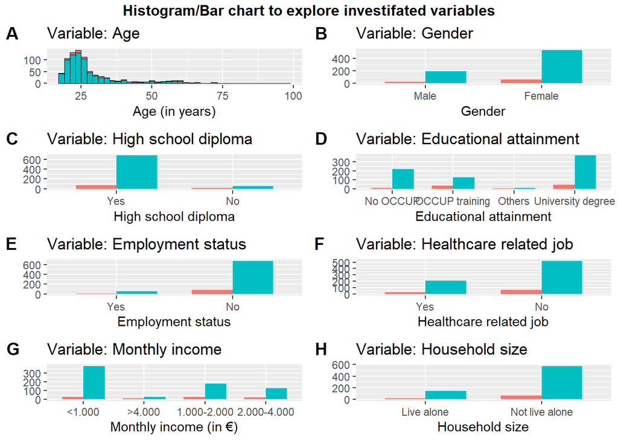

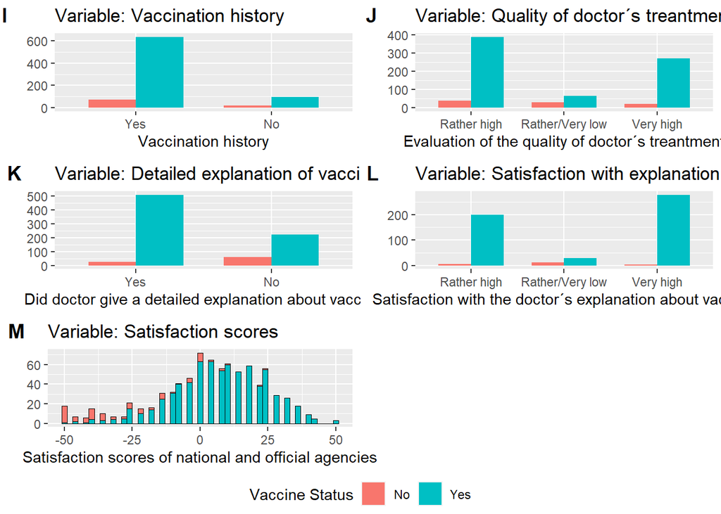

# Modeling

## Univariable Regression

Descriptive statistics of selected variables for modeling

|  | Level |  | N | % |  | N | % |
| --- | --- | --- | --- | --- | --- | --- | --- |
| Sex | Divers |  | 3 | 3.3 |  | 6 | 0.8 |
|  | Männlich |  | 23 | 25.3 |  | 197 | 26.9 |
|  | Weiblich |  | 64 | 70.3 |  | 528 | 72.1 |
|  | <Missing> |  | 1 | 1.1 |  | 1 | 0.1 |
| Abitur | Ja |  | 71 | 78.0 |  | 678 | 92.6 |
|  | Nein |  | 19 | 20.9 |  | 51 | 7.0 |
|  | <Missing> |  | 1 | 1.1 |  | 3 | 0.4 |
| Educational_attainment | No occupational degree |  | 10 | 11.0 |  | 218 | 29.8 |
|  | Occupational training |  | 34 | 37.4 |  | 125 | 17.1 |
|  | Others |  | 2 | 2.2 |  | 10 | 1.4 |
|  | University degree |  | 43 | 47.3 |  | 371 | 50.7 |
|  | <Missing> |  | 2 | 2.2 |  | 8 | 1.1 |
| Employment_status | Ja |  | 5 | 5.5 |  | 57 | 7.8 |
|  | Nein |  | 86 | 94.5 |  | 675 | 92.2 |
| Healthcare_related_job | Ja |  | 25 | 27.5 |  | 210 | 28.7 |
|  | Nein |  | 66 | 72.5 |  | 522 | 71.3 |
| Monthly_income | <1.000 |  | 27 | 29.7 |  | 378 | 51.6 |
|  | >4.000 |  | 10 | 11.0 |  | 26 | 3.6 |
|  | 1.000-2.000 |  | 29 | 31.9 |  | 176 | 24.0 |
|  | 2.000-4.000 |  | 20 | 22.0 |  | 127 | 17.3 |
|  | <Missing> |  | 5 | 5.5 |  | 25 | 3.4 |
| Household_size | Alleine leben |  | 20 | 22.0 |  | 147 | 20.1 |
|  | Nicht alleine leben |  | 65 | 71.4 |  | 573 | 78.3 |
|  | <Missing> |  | 6 | 6.6 |  | 12 | 1.6 |
| ImpfHistory | Ja |  | 71 | 78.0 |  | 636 | 86.9 |
|  | Nein |  | 20 | 22.0 |  | 95 | 13.0 |
|  | <Missing> |  | 0 | 0.0 |  | 1 | 0.1 |
| quality_doctor_treantment | Rather high |  | 37 | 40.7 |  | 388 | 53.0 |
|  | Rather/Very low |  | 30 | 33.0 |  | 65 | 8.9 |
|  | Very high |  | 21 | 23.1 |  | 270 | 36.9 |
|  | <Missing> |  | 3 | 3.3 |  | 9 | 1.2 |
| zapaImpf | Ja |  | 25 | 27.5 |  | 507 | 69.3 |
|  | Nein |  | 62 | 68.1 |  | 221 | 30.2 |
|  | <Missing> |  | 4 | 4.4 |  | 4 | 0.5 |
| Satisfaction_doctor_explanation | Rather high |  | 6 | 6.6 |  | 200 | 27.3 |
|  | Rather/Very low |  | 13 | 14.3 |  | 29 | 4.0 |
|  | Very high |  | 5 | 5.5 |  | 277 | 37.8 |
|  | <Missing> |  | 67 | 73.6 |  | 226 | 30.9 |

```
##  [1] "ImpfZust"                        "ImpfMot"
##  [3] "PersoKenn"                       "KennErkr"
##  [5] "ImpGrund[beruf]"                 "ImpGrund[risiko]"
##  [7] "ImpGrund[norm]"                  "ImpGrund[gesfam]"
##  [9] "ImpGrund[sozum]"                 "ImpGrund[gesell]"
## [11] "ImpGrund[geswesent]"             "GesuZuK"
## [13] "GesuZuPsy"                       "Sex"
## [15] "age"                             "Schulab"
## [17] "BerufAb"                         "TaetGes"
## [19] "ZeitInfo"                        "zapaQualBe"
## [21] "zapaImpf"                        "AufklAkt"
## [23] "ZufriedAufk"                     "ImpDos"
## [25] "ErwerbStat[1]"                   "ErwerbStat[2]"
## [27] "ErwerbStat[3]"                   "ErwerbStat[4]"
## [29] "ErwerbStat[5]"                   "ErwerbStat[6]"
```

[output cut: 19 more lines]

Univariate logistic regression for age

|  | ImpfZust |  |  |
| --- | --- | --- | --- |
| Predictors | Odds Ratios | CI | p |
| (Intercept) | 28.79 | 16.51 – 51.21 | **<0.001** |
| age | 0.96 | 0.95 – 0.98 | **<0.001** |
| Observations | 823 |  |  |
| R<sup>2</sup> Tjur | 0.035 |  |  |

Univariate logistic regression for Sex

|  | ImpfZust |  |  |
| --- | --- | --- | --- |
| Predictors | Odds Ratios | CI | p |
| (Intercept) | 8.57 | 5.69 – 13.55 | **<0.001** |
| Sex [Weiblich] | 0.96 | 0.57 – 1.57 | 0.884 |
| Observations | 812 |  |  |
| R<sup>2</sup> Tjur | 0.000 |  |  |

Univariate logistic regression for Abitur

|  | ImpfZust |  |  |
| --- | --- | --- | --- |
| Predictors | Odds Ratios | CI | p |
| (Intercept) | 2.68 | 1.61 – 4.66 | **<0.001** |
| Abitur [Ja] | 3.56 | 1.95 – 6.27 | **<0.001** |
| Observations | 819 |  |  |
| R<sup>2</sup> Tjur | 0.025 |  |  |

Univariate logistic regression for Educational attainment

|  | ImpfZust |  |  |
| --- | --- | --- | --- |
| Predictors | Odds Ratios | CI | p |
| (Intercept) | 21.80 | 12.22 – 44.00 | **<0.001** |
| Educational attainment [Occupational training] | 0.17 | 0.08 – 0.34 | **<0.001** |
| Educational attainment [Others] | 0.23 | 0.05 – 1.62 | 0.079 |
| Educational attainment [University degree] | 0.40 | 0.18 – 0.77 | **0.010** |
| Observations | 813 |  |  |
| R<sup>2</sup> Tjur | 0.035 |  |  |

Univariate logistic regression for Employment status

|  | ImpfZust |  |  |
| --- | --- | --- | --- |
| Predictors | Odds Ratios | CI | p |
| (Intercept) | 7.85 | 6.31 – 9.89 | **<0.001** |
| Employment status [Ja] | 1.45 | 0.62 – 4.25 | 0.437 |
| Observations | 823 |  |  |
| R<sup>2</sup> Tjur | 0.001 |  |  |

Univariate logistic regression for Healthcare_related_job

|  | ImpfZust |  |  |
| --- | --- | --- | --- |
| Predictors | Odds Ratios | CI | p |
| (Intercept) | 7.91 | 6.17 – 10.31 | **<0.001** |
| Healthcare related job [Ja] | 1.06 | 0.66 – 1.76 | 0.809 |
| Observations | 823 |  |  |
| R<sup>2</sup> Tjur | 0.000 |  |  |

Univariate logistic regression for Monthly_income

|  | ImpfZust |  |  |
| --- | --- | --- | --- |
| Predictors | Odds Ratios | CI | p |
| (Intercept) | 14.00 | 9.67 – 21.18 | **<0.001** |
| Monthly income [>4 000] | 0.19 | 0.08 – 0.44 | **<0.001** |
| Monthly_income1.000-2.000 | 0.43 | 0.25 – 0.75 | **0.003** |
| Monthly_income2.000-4.000 | 0.45 | 0.25 – 0.85 | **0.011** |
| Observations | 793 |  |  |
| R<sup>2</sup> Tjur | 0.027 |  |  |

Univariate logistic regression for Household_size

|  | ImpfZust |  |  |
| --- | --- | --- | --- |
| Predictors | Odds Ratios | CI | p |
| (Intercept) | 7.35 | 4.72 – 12.09 | **<0.001** |
| Household size [Nicht alleine leben] | 1.20 | 0.69 – 2.01 | 0.504 |
| Observations | 805 |  |  |
| R<sup>2</sup> Tjur | 0.001 |  |  |

Univariate logistic regression for ImpfHistory

|  | ImpfZust |  |  |
| --- | --- | --- | --- |
| Predictors | Odds Ratios | CI | p |
| (Intercept) | 4.75 | 3.00 – 7.91 | **<0.001** |
| ImpfHistory [Ja] | 1.89 | 1.07 – 3.19 | **0.022** |
| Observations | 822 |  |  |
| R<sup>2</sup> Tjur | 0.007 |  |  |

Univariate logistic regression for Evaluation of the quality of doctor treantment

|  | ImpfZust |  |  |
| --- | --- | --- | --- |
| Predictors | Odds Ratios | CI | p |
| (Intercept) | 2.17 | 1.42 – 3.38 | **<0.001** |
| quality doctor treantment [Rather high] | 4.84 | 2.79 – 8.38 | **<0.001** |
| quality doctor treantment [Very high] | 5.93 | 3.21 – 11.16 | **<0.001** |
| Observations | 811 |  |  |
| R<sup>2</sup> Tjur | 0.059 |  |  |

Univariate logistic regression for Did the doctor give a detailed explanation about the corona vaccine

|  | ImpfZust |  |  |
| --- | --- | --- | --- |
| Predictors | Odds Ratios | CI | p |
| (Intercept) | 3.56 | 2.71 – 4.76 | **<0.001** |
| zapaImpf [Ja] | 5.69 | 3.53 – 9.44 | **<0.001** |
| Observations | 815 |  |  |
| R<sup>2</sup> Tjur | 0.070 |  |  |

Univariate logistic regression for Satisfaction with the doctor explanation about vaccine

|  | ImpfZust |  |  |
| --- | --- | --- | --- |
| Predictors | Odds Ratios | CI | p |
| (Intercept) | 2.23 | 1.18 – 4.44 | **0.016** |
| Satisfaction doctor explanation [Rather high] | 14.94 | 5.47 – 45.47 | **<0.001** |
| Satisfaction doctor explanation [Very high] | 24.83 | 8.71 – 82.07 | **<0.001** |
| Observations | 530 |  |  |
| R<sup>2</sup> Tjur | 0.140 |  |  |

|  | ImpfZust |  |  |
| --- | --- | --- | --- |
| Predictors | Odds Ratios | CI | p |
| (Intercept) | 18.57 | 12.90 – 28.00 | **<0.001** |
| Govtrust | 1.10 | 1.08 – 1.12 | **<0.001** |
| Observations | 823 |  |  |
| R<sup>2</sup> Tjur | 0.400 |  |  |

## Full model

```
## tibble [823 x 14] (S3: tbl_df/tbl/data.frame)
##  $ ImpfZust                       : Factor w/ 2 levels "Nein","Ja": 2 2 2 2 2 2 2 2 2 2 ...
##  $ age                            : num [1:823] 27 24 25 23 31 27 25 26 25 28 ...
##  $ Sex                            : Factor w/ 3 levels "Männlich","Divers",..: 3 3 3 3 1 3 1 3 3 1 ...
##  $ Abitur                         : Factor w/ 2 levels "Nein","Ja": 2 2 2 2 2 2 2 2 2 2 ...
##  $ Educational_attainment         : Factor w/ 4 levels "No occupational degree",..: 2 4 1 4 4 4 4 4 1 NA ...
##  $ Employment_status              : Factor w/ 2 levels "Nein","Ja": 1 1 1 1 1 1 1 1 1 1 ...
##  $ Healthcare_related_job         : Factor w/ 2 levels "Nein","Ja": 1 2 2 2 2 2 1 2 1 1 ...
##  $ Monthly_income                 : Factor w/ 4 levels "<1.000",">4.000",..: 3 4 3 3 4 3 2 1 1 1 ...
##  $ Household_size                 : Factor w/ 2 levels "Alleine leben",..: 1 2 2 1 1 2 1 2 2 2 ...
##  $ ImpfHistory                    : Factor w/ 2 levels "Nein","Ja": 2 2 2 2 2 2 2 2 2 2 ...
##  $ quality_doctor_treantment      : Factor w/ 3 levels "Rather/Very low",..: 2 2 2 2 2 2 3 2 2 2 ...
##  $ zapaImpf                       : Factor w/ 2 levels "Nein","Ja": 2 2 2 1 2 1 1 1 2 2 ...
##  $ Satisfaction_doctor_explanation: Factor w/ 3 levels "Rather/Very low",..: 3 3 3 NA 2 NA NA NA 3 3 ...
##  $ Govtrust                       : num [1:823] 3.57 17.86 10.71 32.14 10.71 ...
```

|  | Term | VIF | SE_factor |
| --- | --- | --- | --- |
| 1 | age | 1.364080 | 1.167938 |
| 2 | Abitur | 1.592471 | 1.261932 |
| 3 | Educational_attainment | 1.792446 | 1.338823 |
| 4 | Monthly_income | 1.472256 | 1.213365 |
| 5 | ImpfHistory | 1.112416 | 1.054711 |
| 6 | quality_doctor_treantment | 1.219999 | 1.104536 |
| 7 | Govtrust | 1.107722 | 1.052484 |
| 8 | zapaImpf | 1.116139 | 1.056475 |

|  | ImpfZust |  |  |
| --- | --- | --- | --- |
| Predictors | Odds Ratios | CI | p |
| (Intercept) | 18.85 | 2.96 – 128.76 | **0.002** |
| age | 0.98 | 0.95 – 1.01 | 0.128 |
| Abitur [Ja] | 0.77 | 0.24 – 2.40 | 0.659 |
| Educational attainment [Occupational training] | 0.33 | 0.10 – 1.01 | 0.056 |
| Educational attainment [Others] | 2.60 | 0.23 – 58.86 | 0.487 |
| Educational attainment [University degree] | 0.68 | 0.23 – 1.86 | 0.465 |
| Monthly income [>4 000] | 0.47 | 0.12 – 1.89 | 0.276 |
| Monthly_income1.000-2.000 | 0.42 | 0.17 – 0.99 | **0.048** |
| Monthly_income2.000-4.000 | 0.77 | 0.30 – 2.00 | 0.583 |
| ImpfHistory [Ja] | 1.70 | 0.68 – 4.09 | 0.245 |
| quality doctor treantment [Rather high] | 2.50 | 1.03 – 5.95 | **0.040** |
| quality doctor treantment [Very high] | 2.49 | 0.90 – 6.90 | 0.078 |
| Govtrust | 1.10 | 1.08 – 1.12 | **<0.001** |
| zapaImpf [Ja] | 3.96 | 2.01 – 8.04 | **<0.001** |
| Observations | 772 |  |  |
| R<sup>2</sup> Tjur | 0.496 |  |  |

## PMM imputation

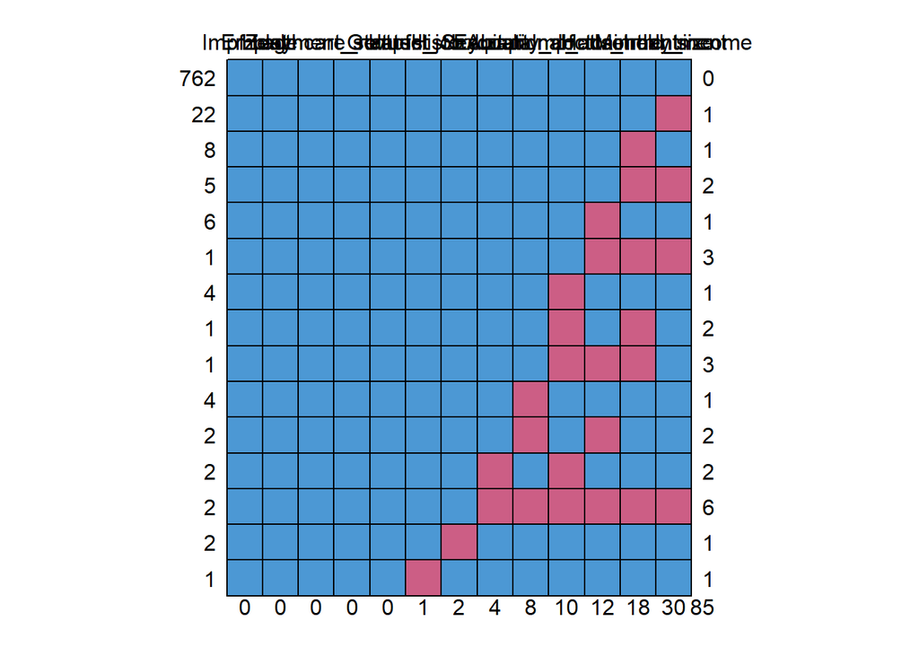

```
##     ImpfZust age Employment_status Healthcare_related_job Govtrust ImpfHistory
## 762        1   1                 1                      1        1           1
## 22         1   1                 1                      1        1           1
## 8          1   1                 1                      1        1           1
## 5          1   1                 1                      1        1           1
## 6          1   1                 1                      1        1           1
## 1          1   1                 1                      1        1           1
## 4          1   1                 1                      1        1           1
## 1          1   1                 1                      1        1           1
## 1          1   1                 1                      1        1           1
## 4          1   1                 1                      1        1           1
## 2          1   1                 1                      1        1           1
## 2          1   1                 1                      1        1           1
## 2          1   1                 1                      1        1           1
## 2          1   1                 1                      1        1           1
```

[output cut: 36 more lines]

Mice pooling results

| term | estimate | std.error | statistic | df | p.value |
| --- | --- | --- | --- | --- | --- |
| (Intercept) | 3.0804611 | 0.8992074 | 3.4257514 | 692.7471 | 0.0006493 |
| age | -0.0265483 | 0.0152096 | -1.7454971 | 800.5196 | 0.0812820 |
| AbiturJa | -0.4986755 | 0.5626833 | -0.8862455 | 723.2114 | 0.3757799 |
| Educational_attainmentOccupational training | -1.1193501 | 0.5517910 | -2.0285760 | 341.2444 | 0.0432777 |
| Educational_attainmentOthers | 0.9752669 | 1.3421204 | 0.7266612 | 799.9066 | 0.4676461 |
| Educational_attainmentUniversity degree | -0.1997180 | 0.5119129 | -0.3901405 | 395.2560 | 0.6966428 |
| Monthly_income>4.000 | -0.9920380 | 0.6572837 | -1.5092995 | 692.4133 | 0.1316784 |
| Monthly_income1.000-2.000 | -0.8564124 | 0.4269521 | -2.0058748 | 592.5944 | 0.0453236 |
| Monthly_income2.000-4.000 | -0.2623784 | 0.4605374 | -0.5697223 | 667.3443 | 0.5690578 |
| ImpfHistoryJa | 0.6363045 | 0.4216906 | 1.5089368 | 731.1501 | 0.1317469 |
| quality_doctor_treantmentRather high | 0.8609976 | 0.4415239 | 1.9500587 | 211.5123 | 0.0524906 |
| quality_doctor_treantmentVery high | 0.7932714 | 0.4965306 | 1.5976282 | 468.3282 | 0.1108002 |
| Govtrust | 0.0907022 | 0.0092012 | 9.8576319 | 790.0682 | 0.0000000 |
| zapaImpfJa | 1.2963785 | 0.3479298 | 3.7259767 | 342.2445 | 0.0002275 |

[output not shown]

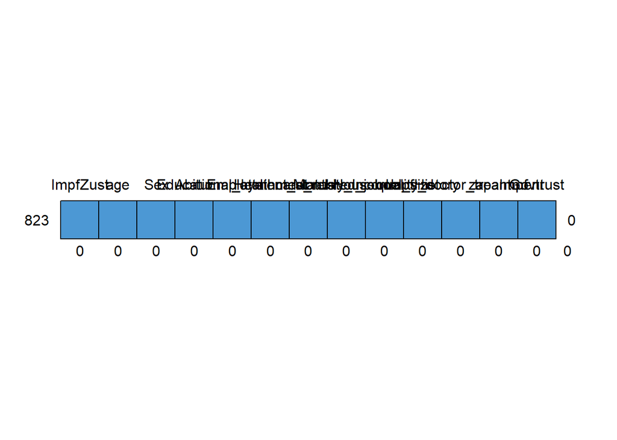

```
##     ImpfZust age Sex Abitur Educational_attainment Employment_status
## 823        1   1   1      1                      1                 1
##            0   0   0      0                      0                 0
##     Healthcare_related_job Monthly_income Household_size ImpfHistory
## 823                      1              1              1           1
##                          0              0              0           0
##     quality_doctor_treantment zapaImpf Govtrust
## 823                         1        1        1 0
##                             0        0        0 0
```

[output not shown]

[output cut: 176 more lines]

[output not shown]

|  | Term | VIF | SE_factor |
| --- | --- | --- | --- |
| 1 | age | 1.406113 | 1.185796 |
| 2 | Abitur | 1.635809 | 1.278987 |
| 3 | Educational_attainment | 1.844219 | 1.358020 |
| 4 | Monthly_income | 1.496381 | 1.223266 |
| 5 | ImpfHistory | 1.128101 | 1.062121 |
| 6 | quality_doctor_treantment | 1.196136 | 1.093680 |
| 7 | Govtrust | 1.107257 | 1.052263 |
| 8 | zapaImpf | 1.124787 | 1.060560 |

|  | ImpfZust |  |  | ImpfZust |  |  |
| --- | --- | --- | --- | --- | --- | --- |
| Predictors | Odds Ratios | CI | p | Odds Ratios | CI | p |
| (Intercept) | 18.85 | 2.96 – 128.76 | **0.002** | 24.00 | 4.29 – 142.15 | **<0.001** |
| age | 0.98 | 0.95 – 1.01 | 0.128 | 0.97 | 0.95 – 1.00 | 0.073 |
| Abitur [Ja] | 0.77 | 0.24 – 2.40 | 0.659 | 0.57 | 0.19 – 1.68 | 0.315 |
| Educational attainment [Occupational training] | 0.33 | 0.10 – 1.01 | 0.056 | 0.30 | 0.10 – 0.83 | **0.023** |
| Educational attainment [Others] | 2.60 | 0.23 – 58.86 | 0.487 | 2.52 | 0.24 – 54.32 | 0.487 |
| Educational attainment [University degree] | 0.68 | 0.23 – 1.86 | 0.465 | 0.80 | 0.29 – 2.07 | 0.647 |
| Monthly income [>4 000] | 0.47 | 0.12 – 1.89 | 0.276 | 0.40 | 0.11 – 1.47 | 0.159 |
| Monthly_income1.000-2.000 | 0.42 | 0.17 – 0.99 | **0.048** | 0.46 | 0.20 – 1.04 | 0.061 |
| Monthly_income2.000-4.000 | 0.77 | 0.30 – 2.00 | 0.583 | 0.74 | 0.31 – 1.81 | 0.509 |
| ImpfHistory [Ja] | 1.70 | 0.68 – 4.09 | 0.245 | 1.91 | 0.83 – 4.25 | 0.118 |
| quality doctor treantment [Rather high] | 2.50 | 1.03 – 5.95 | **0.040** | 2.50 | 1.10 – 5.60 | **0.027** |
| quality doctor treantment [Very high] | 2.49 | 0.90 – 6.90 | 0.078 | 2.28 | 0.89 – 5.85 | 0.084 |
| Govtrust | 1.10 | 1.08 – 1.12 | **<0.001** | 1.09 | 1.08 – 1.12 | **<0.001** |
| zapaImpf [Ja] | 3.96 | 2.01 – 8.04 | **<0.001** | 3.19 | 1.68 – 6.16 | **<0.001** |
| Observations | 772 |  |  | 823 |  |  |
| R<sup>2</sup> Tjur | 0.496 |  |  | 0.479 |  |  |

## Submodel 1 step

|  | ImpfZust |  |  | ImpfZust |  |  |
| --- | --- | --- | --- | --- | --- | --- |
| Predictors | Odds Ratios | CI | p | Odds Ratios | CI | p |
| (Intercept) | 18.85 | 2.96 – 128.76 | **0.002** | 18.89 | 5.70 – 69.92 | **<0.001** |
| age | 0.98 | 0.95 – 1.01 | 0.128 | 0.97 | 0.94 – 1.00 | 0.054 |
| Abitur [Ja] | 0.77 | 0.24 – 2.40 | 0.659 |  |  |  |
| Educational attainment [Occupational training] | 0.33 | 0.10 – 1.01 | 0.056 | 0.26 | 0.08 – 0.75 | **0.016** |
| Educational attainment [Others] | 2.60 | 0.23 – 58.86 | 0.487 | 2.46 | 0.21 – 54.52 | 0.519 |
| Educational attainment [University degree] | 0.68 | 0.23 – 1.86 | 0.465 | 0.59 | 0.21 – 1.56 | 0.309 |
| Monthly income [>4 000] | 0.47 | 0.12 – 1.89 | 0.276 |  |  |  |
| Monthly_income1.000-2.000 | 0.42 | 0.17 – 0.99 | **0.048** |  |  |  |
| Monthly_income2.000-4.000 | 0.77 | 0.30 – 2.00 | 0.583 |  |  |  |
| ImpfHistory [Ja] | 1.70 | 0.68 – 4.09 | 0.245 |  |  |  |
| quality doctor treantment [Rather high] | 2.50 | 1.03 – 5.95 | **0.040** | 3.05 | 1.29 – 7.21 | **0.011** |
| quality doctor treantment [Very high] | 2.49 | 0.90 – 6.90 | 0.078 | 3.71 | 1.39 – 10.14 | **0.009** |
| Govtrust | 1.10 | 1.08 – 1.12 | **<0.001** | 1.09 | 1.08 – 1.12 | **<0.001** |
| zapaImpf [Ja] | 3.96 | 2.01 – 8.04 | **<0.001** | 3.50 | 1.79 – 7.02 | **<0.001** |
| Observations | 772 |  |  | 762 |  |  |
| R<sup>2</sup> Tjur | 0.496 |  |  | 0.497 |  |  |

## Submodel 2 best

|  | ImpfZust |  |  | ImpfZust |  |  |
| --- | --- | --- | --- | --- | --- | --- |
| Predictors | Odds Ratios | CI | p | Odds Ratios | CI | p |
| (Intercept) | 18.85 | 2.96 – 128.76 | **0.002** | 22.53 | 6.46 – 88.26 | **<0.001** |
| age | 0.98 | 0.95 – 1.01 | 0.128 | 0.97 | 0.94 – 1.00 | **0.038** |
| Abitur [Ja] | 0.77 | 0.24 – 2.40 | 0.659 |  |  |  |
| Educational attainment [Occupational training] | 0.33 | 0.10 – 1.01 | 0.056 | 0.24 | 0.08 – 0.66 | **0.008** |
| Educational attainment [Others] | 2.60 | 0.23 – 58.86 | 0.487 | 2.77 | 0.24 – 55.93 | 0.447 |
| Educational attainment [University degree] | 0.68 | 0.23 – 1.86 | 0.465 | 0.53 | 0.19 – 1.37 | 0.207 |
| Monthly income [>4 000] | 0.47 | 0.12 – 1.89 | 0.276 |  |  |  |
| Monthly_income1.000-2.000 | 0.42 | 0.17 – 0.99 | **0.048** |  |  |  |
| Monthly_income2.000-4.000 | 0.77 | 0.30 – 2.00 | 0.583 |  |  |  |
| ImpfHistory [Ja] | 1.70 | 0.68 – 4.09 | 0.245 | 1.94 | 0.80 – 4.52 | 0.129 |
| quality doctor treantment [Rather high] | 2.50 | 1.03 – 5.95 | **0.040** | 3.20 | 1.37 – 7.43 | **0.007** |
| quality doctor treantment [Very high] | 2.49 | 0.90 – 6.90 | 0.078 | 4.77 | 1.85 – 12.71 | **0.001** |
| Govtrust | 1.10 | 1.08 – 1.12 | **<0.001** | 1.10 | 1.08 – 1.12 | **<0.001** |
| zapaImpf [Ja] | 3.96 | 2.01 – 8.04 | **<0.001** |  |  |  |
| Observations | 772 |  |  | 762 |  |  |
| R<sup>2</sup> Tjur | 0.496 |  |  | 0.471 |  |  |

## Submodel 3 ElasticNet penalized regression

|  | ImpfZust |  |  | ImpfZust |  |  |
| --- | --- | --- | --- | --- | --- | --- |
| Predictors | Odds Ratios | CI | p | Odds Ratios | CI | p |
| (Intercept) | 18.85 | 2.96 – 128.76 | **0.002** | 35.02 | 13.99 – 93.17 | **<0.001** |
| age | 0.98 | 0.95 – 1.01 | 0.128 | 0.96 | 0.94 – 0.98 | **0.002** |
| Abitur [Ja] | 0.77 | 0.24 – 2.40 | 0.659 |  |  |  |
| Educational attainment [Occupational training] | 0.33 | 0.10 – 1.01 | 0.056 |  |  |  |
| Educational attainment [Others] | 2.60 | 0.23 – 58.86 | 0.487 |  |  |  |
| Educational attainment [University degree] | 0.68 | 0.23 – 1.86 | 0.465 |  |  |  |
| Monthly income [>4 000] | 0.47 | 0.12 – 1.89 | 0.276 |  |  |  |
| Monthly_income1.000-2.000 | 0.42 | 0.17 – 0.99 | **0.048** |  |  |  |
| Monthly_income2.000-4.000 | 0.77 | 0.30 – 2.00 | 0.583 |  |  |  |
| ImpfHistory [Ja] | 1.70 | 0.68 – 4.09 | 0.245 |  |  |  |
| quality doctor treantment [Rather high] | 2.50 | 1.03 – 5.95 | **0.040** |  |  |  |
| quality doctor treantment [Very high] | 2.49 | 0.90 – 6.90 | 0.078 |  |  |  |
| Govtrust | 1.10 | 1.08 – 1.12 | **<0.001** | 1.09 | 1.08 – 1.12 | **<0.001** |
| zapaImpf [Ja] | 3.96 | 2.01 – 8.04 | **<0.001** | 4.28 | 2.26 – 8.37 | **<0.001** |
| Observations | 772 |  |  | 762 |  |  |
| R<sup>2</sup> Tjur | 0.496 |  |  | 0.465 |  |  |

## Metrics

Results of models compason

| Model | logLik | AIC | BIC | df.residual | Tjur_R2 |
| --- | --- | --- | --- | --- | --- |
| Full model | -129.9919 | 287.9838 | 353.0696 | 758 | 0.496 |
| Full model imputed | -146.4968 | 320.9936 | 386.9750 | 809 | 0.479 |
| Best Model 1 | -125.8551 | 269.7101 | 311.4337 | 753 | 0.497 |
| Best Model 2 | -131.5748 | 281.1495 | 322.8731 | 753 | 0.471 |
| Best Model 3 | -133.4688 | 274.9375 | 293.4813 | 758 | 0.465 |